# Treemap Visualisation with R

Author

Cheng yuanyuan

## 1 Overview

Treemap is a useful visualisation method for hierarchical data. It uses nested rectangles to show structure and size at the same time.

In this exercise, Singapore private residential transaction data is used. The size of each rectangle represents the number of units sold. The colour intensity represents the median unit price.

The focus is not to make the most complicated treemap. The focus is to make a readable treemap.

This exercise covers:

- importing transaction data;
- preparing grouped summaries with `group_by()` and `summarise()`;
- designing treemaps with the `treemap` package;
- designing cleaner ggplot-style treemaps with `treemapify`;
- understanding how interactive treemaps can be created with `d3treeR`.

## 2 Installing and launching R packages

```r
if (!requireNamespace("pacman", quietly = TRUE)) {
  install.packages("pacman")
}

pacman::p_load(
  tidyverse,
  treemap,
  treemapify,
  scales
)
```

## 3 Data wrangling

### 3.1 Importing the data set

```r
if (!file.exists("data/realis2018.csv")) {
  stop("The file data/realis2018.csv is missing. Please put realis2018.csv inside the data folder.")
}

realis2018 <- read_csv("data/realis2018.csv")

glimpse(realis2018)
```

```
Rows: 23,205
Columns: 20
$ `Project Name`                <chr> "ADANA @ THOMSON", "ALANA", "ALANA", "AL…
$ Address                       <chr> "8 Old Upper Thomson Road  #05-03", "156…
$ `No. of Units`                <dbl> 1, 1, 1, 1, 1, 1, 1, 1, 1, 1, 1, 1, 1, 1…
$ `Area (sqm)`                  <dbl> 52, 284, 256, 256, 277, 285, 234, 155, 1…
$ `Type of Area`                <chr> "Strata", "Strata", "Strata", "Strata", …
$ `Transacted Price ($)`        <dbl> 888888, 2530000, 2390863, 2450000, 19800…
$ `Nett Price($)`               <chr> "-", "-", "2382517", "2441654", "-", "-"…
$ `Unit Price ($ psm)`          <dbl> 17094, 8908, 9307, 9538, 7148, 6947, 147…
$ `Unit Price ($ psf)`          <dbl> 1588, 828, 865, 886, 664, 645, 1371, 149…
$ `Sale Date`                   <chr> "4-Jul-18", "5-Oct-18", "9-Jun-18", "14-…
$ `Property Type`               <chr> "Apartment", "Terrace House", "Terrace H…
$ Tenure                        <chr> "Freehold", "103 Yrs From 12/08/2013", "…
$ `Completion Date`             <chr> "2018", "2018", "2018", "2018", "2008", …
$ `Type of Sale`                <chr> "New Sale", "Sub Sale", "New Sale", "New…
$ `Purchaser Address Indicator` <chr> "Private", "Private", "HDB", "N.A", "Pri…
$ `Postal District`             <dbl> 20, 28, 28, 28, 26, 26, 26, 26, 26, 26, …
$ `Postal Sector`               <dbl> 57, 80, 80, 80, 78, 78, 78, 78, 78, 78, …
$ `Postal Code`                 <dbl> 573868, 804555, 804529, 804540, 786300, …
$ `Planning Region`             <chr> "North East Region", "North East Region"…
$ `Planning Area`               <chr> "Ang Mo Kio", "Ang Mo Kio", "Ang Mo Kio"…
```

### 3.2 Checking column names

Different versions of the same dataset may use slightly different column names. The code below detects the required columns automatically.

```r
names(realis2018)
```

```
 [1] "Project Name"                "Address"
 [3] "No. of Units"                "Area (sqm)"
 [5] "Type of Area"                "Transacted Price ($)"
 [7] "Nett Price($)"               "Unit Price ($ psm)"
 [9] "Unit Price ($ psf)"          "Sale Date"
[11] "Property Type"               "Tenure"
[13] "Completion Date"             "Type of Sale"
[15] "Purchaser Address Indicator" "Postal District"
[17] "Postal Sector"               "Postal Code"
[19] "Planning Region"             "Planning Area"
```

```r
pick_col <- function(possible_names, data_names) {
  result <- intersect(possible_names, data_names)
  if (length(result) == 0) {
    return(NA_character_)
  }
  result[1]
}

units_col <- pick_col(
  c("No. of Units", "Number of Units", "No of Units"),
  names(realis2018)
)

area_col <- pick_col(
  c("Area (sqm)", "Area (SQM)", "Area SQM"),
  names(realis2018)
)

unit_price_col <- pick_col(
  c("Unit Price ($ psm)", "Unit Price ($ PSM)", "Unit Price ($psm)"),
  names(realis2018)
)

transacted_price_col <- pick_col(
  c("Transacted Price ($)", "Transacted Price"),
  names(realis2018)
)

needed_cols <- c(
  "Project Name",
  "Planning Region",
  "Planning Area",
  "Property Type",
  "Type of Sale",
  units_col,
  area_col,
  unit_price_col,
  transacted_price_col
)

if (any(is.na(needed_cols))) {
  stop("Some required columns are missing. Please check names(realis2018).")
}
```

### 3.3 Grouped summaries without the pipe

```r
realis2018_grouped <- group_by(
  realis2018,
  `Project Name`,
  `Planning Region`,
  `Planning Area`,
  `Property Type`,
  `Type of Sale`
)

realis2018_summarised_1 <- summarise(
  realis2018_grouped,
  `Total Unit Sold` = sum(.data[[units_col]], na.rm = TRUE),
  `Total Area` = sum(.data[[area_col]], na.rm = TRUE),
  `Median Unit Price ($ psm)` = median(.data[[unit_price_col]], na.rm = TRUE),
  `Median Transacted Price` = median(.data[[transacted_price_col]], na.rm = TRUE),
  .groups = "drop"
)

head(realis2018_summarised_1)
```

```
# A tibble: 6 × 9
  `Project Name`     `Planning Region` `Planning Area` `Property Type`
  <chr>              <chr>             <chr>           <chr>
1 # 1 LOFT           Central Region    Geylang         Apartment
2 # 1 SUITES         Central Region    Geylang         Apartment
3 1 CANBERRA         North Region      Yishun          Executive Condominium
4 1 KING ALBERT PARK Central Region    Bukit Timah     Condominium
5 10 EVELYN          Central Region    Novena          Apartment
6 10 SHELFORD        Central Region    Bukit Timah     Apartment
# ℹ 5 more variables: `Type of Sale` <chr>, `Total Unit Sold` <dbl>,
#   `Total Area` <dbl>, `Median Unit Price ($ psm)` <dbl>,
#   `Median Transacted Price` <dbl>
```

This method works, but it creates an intermediate object. The pipe method is cleaner.

### 3.4 Grouped summaries with the pipe

```r
realis2018_summarised <- realis2018 %>%
  group_by(
    `Project Name`,
    `Planning Region`,
    `Planning Area`,
    `Property Type`,
    `Type of Sale`
  ) %>%
  summarise(
    `Total Unit Sold` = sum(.data[[units_col]], na.rm = TRUE),
    `Total Area` = sum(.data[[area_col]], na.rm = TRUE),
    `Median Unit Price ($ psm)` = median(.data[[unit_price_col]], na.rm = TRUE),
    `Median Transacted Price` = median(.data[[transacted_price_col]], na.rm = TRUE),
    .groups = "drop"
  )

glimpse(realis2018_summarised)
```

```
Rows: 2,266
Columns: 9
$ `Project Name`              <chr> "# 1 LOFT", "# 1 SUITES", "1 CANBERRA", "1…
$ `Planning Region`           <chr> "Central Region", "Central Region", "North…
$ `Planning Area`             <chr> "Geylang", "Geylang", "Yishun", "Bukit Tim…
$ `Property Type`             <chr> "Apartment", "Apartment", "Executive Condo…
$ `Type of Sale`              <chr> "Resale", "Resale", "Resale", "Resale", "N…
$ `Total Unit Sold`           <dbl> 1, 1, 2, 5, 2, 3, 5, 6, 45, 5, 2, 3, 4, 3,…
$ `Total Area`                <dbl> 51, 52, 198, 565, 96, 175, 722, 1426, 2447…
$ `Median Unit Price ($ psm)` <dbl> 13098.0, 12212.0, 9056.5, 13986.0, 26669.5…
$ `Median Transacted Price`   <dbl> 668000, 635000, 896944, 1700000, 1280090, …
```

## 4 Selecting resale condominium records

```r
realis2018_selected <- realis2018_summarised %>%
  filter(
    str_detect(`Property Type`, regex("condominium", ignore_case = TRUE)),
    str_detect(`Type of Sale`, regex("resale", ignore_case = TRUE))
  ) %>%
  filter(
    !is.na(`Total Unit Sold`),
    !is.na(`Median Unit Price ($ psm)`),
    `Total Unit Sold` > 0
  )

if (nrow(realis2018_selected) == 0) {
  realis2018_selected <- realis2018_summarised %>%
    filter(str_detect(`Property Type`, regex("condominium", ignore_case = TRUE))) %>%
    filter(
      !is.na(`Total Unit Sold`),
      !is.na(`Median Unit Price ($ psm)`),
      `Total Unit Sold` > 0
    )
}

if (nrow(realis2018_selected) == 0) {
  stop("No condominium records found. Please check the values in Property Type and Type of Sale.")
}

glimpse(realis2018_selected)
```

```
Rows: 670
Columns: 9
$ `Project Name`              <chr> "1 CANBERRA", "1 KING ALBERT PARK", "3 ORC…
$ `Planning Region`           <chr> "North Region", "Central Region", "Central…
$ `Planning Area`             <chr> "Yishun", "Bukit Timah", "Orchard", "Noven…
$ `Property Type`             <chr> "Executive Condominium", "Condominium", "C…
$ `Type of Sale`              <chr> "Resale", "Resale", "Resale", "Resale", "R…
$ `Total Unit Sold`           <dbl> 2, 5, 4, 8, 3, 14, 8, 12, 16, 48, 8, 5, 2,…
$ `Total Area`                <dbl> 198, 565, 626, 886, 231, 1520, 1496, 1272,…
$ `Median Unit Price ($ psm)` <dbl> 9056.5, 13986.0, 40173.5, 16646.5, 23266.0…
$ `Median Transacted Price`   <dbl> 896944, 1700000, 6392900, 1700000, 1791468…
```

## 5 Designing Treemap with treemap Package

### 5.1 Basic treemap

The three basic arguments of `treemap()` are:

- `index`: hierarchy of the treemap;
- `vSize`: rectangle size;
- `vColor`: rectangle colour.

To avoid a messy chart, this first treemap uses only two hierarchy levels:

```
Planning Region → Planning Area
```

```r
area_summary <- realis2018_selected %>%
  group_by(`Planning Region`, `Planning Area`) %>%
  summarise(
    `Total Unit Sold` = sum(`Total Unit Sold`, na.rm = TRUE),
    `Median Unit Price ($ psm)` = median(`Median Unit Price ($ psm)`, na.rm = TRUE),
    `Median Transacted Price` = median(`Median Transacted Price`, na.rm = TRUE),
    .groups = "drop"
  ) %>%
  filter(`Total Unit Sold` > 0)
```

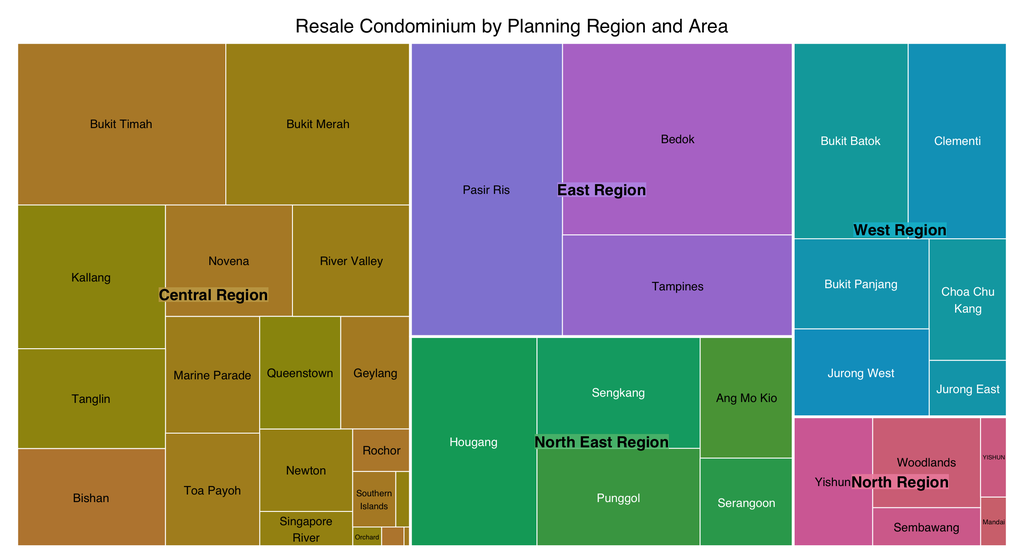

```r
treemap(
  area_summary,
  index = c("Planning Region", "Planning Area"),
  vSize = "Total Unit Sold",
  vColor = "Median Unit Price ($ psm)",
  title = "Resale Condominium by Planning Region and Area",
  title.legend = "Median Unit Price (S$ per sq. m)",
  fontsize.title = 16,
  fontsize.labels = c(13, 10),
  border.col = "white"
)
```

The basic treemap shows the hierarchy, but the colour setting is still not ideal because the `type` argument has not been defined.

### 5.2 Working with vColor and type arguments

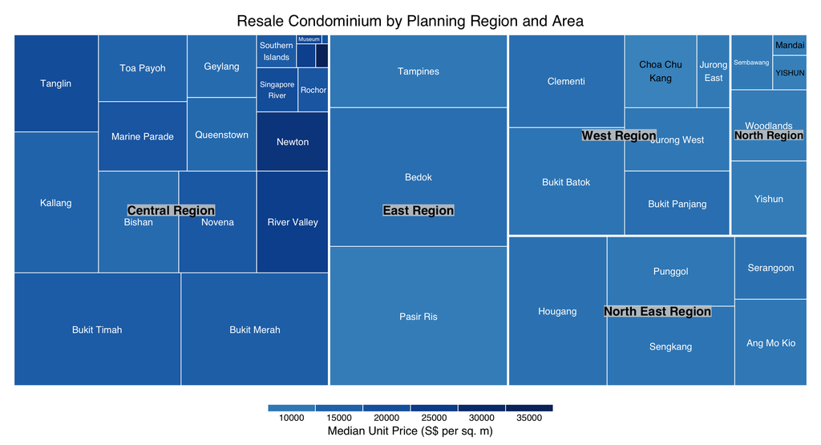

```r
treemap(
  area_summary,
  index = c("Planning Region", "Planning Area"),
  vSize = "Total Unit Sold",
  vColor = "Median Unit Price ($ psm)",
  type = "value",
  palette = "Blues",
  algorithm = "squarified",
  title = "Resale Condominium by Planning Region and Area",
  title.legend = "Median Unit Price (S$ per sq. m)",
  fontsize.title = 16,
  fontsize.labels = c(13, 10),
  border.col = "white"
)
```

With `type = "value"`, colour intensity reflects the median unit price more directly.

### 5.3 Manual colour type

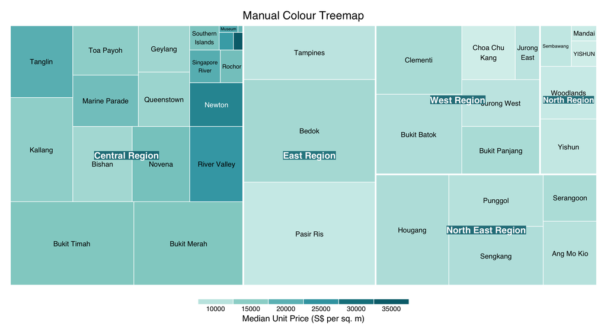

```r
treemap(
  area_summary,
  index = c("Planning Region", "Planning Area"),
  vSize = "Total Unit Sold",
  vColor = "Median Unit Price ($ psm)",
  type = "manual",
  palette = c("#D7F0ED", "#93D1CC", "#3FA7B3", "#006D7A"),
  algorithm = "squarified",
  title = "Manual Colour Treemap",
  title.legend = "Median Unit Price (S$ per sq. m)",
  fontsize.title = 16,
  fontsize.labels = c(13, 10),
  border.col = "white"
)
```

The manual colour version is cleaner because it uses one consistent blue-green palette.

### 5.4 Treemap layout and sortID

The `algorithm` argument controls the rectangle layout. The `sortID` argument controls rectangle ordering.

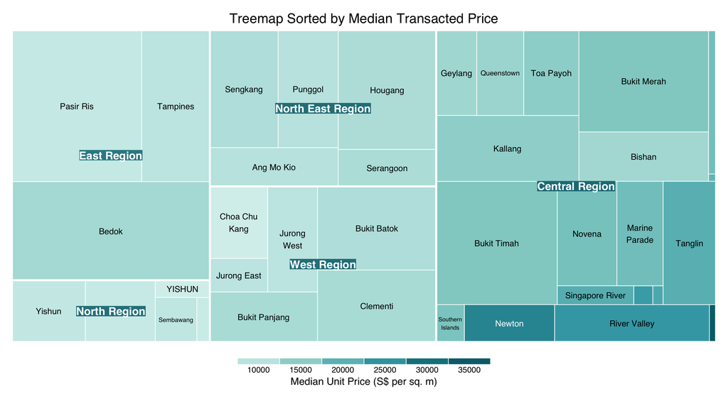

```r
treemap(
  area_summary,
  index = c("Planning Region", "Planning Area"),
  vSize = "Total Unit Sold",
  vColor = "Median Unit Price ($ psm)",
  type = "manual",
  palette = c("#D7F0ED", "#93D1CC", "#3FA7B3", "#006D7A"),
  algorithm = "pivotSize",
  sortID = "Median Transacted Price",
  title = "Treemap Sorted by Median Transacted Price",
  title.legend = "Median Unit Price (S$ per sq. m)",
  fontsize.title = 16,
  fontsize.labels = c(13, 10),
  border.col = "white"
)
```

## 6 Designing Treemap using treemapify Package

The `treemapify` package uses a ggplot2-style syntax. This makes it easier to control the appearance of the chart.

### 6.1 Clean planning-area treemap

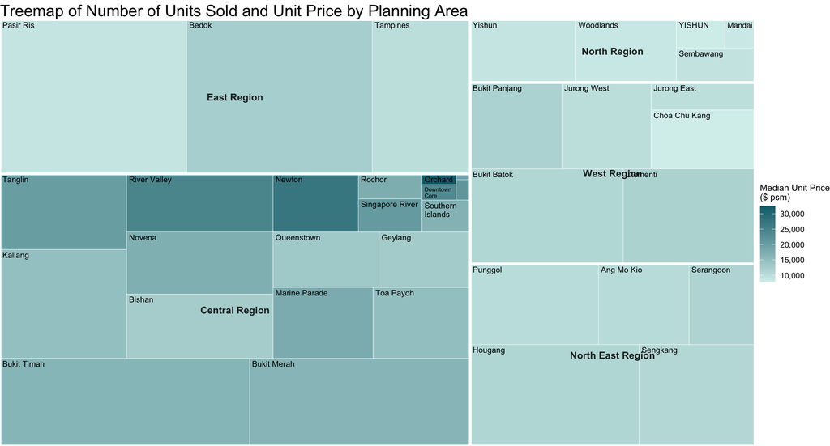

```r
ggplot(
  area_summary,
  aes(
    area = `Total Unit Sold`,
    fill = `Median Unit Price ($ psm)`,
    subgroup = `Planning Region`,
    label = `Planning Area`
  )
) +
  geom_treemap(colour = "white", linewidth = 0.8) +
  geom_treemap_subgroup_border(colour = "white", linewidth = 2) +
  geom_treemap_subgroup_text(
    place = "centre",
    grow = FALSE,
    alpha = 0.85,
    colour = "black",
    fontface = "bold",
    size = 11
  ) +
  geom_treemap_text(
    colour = "black",
    place = "topleft",
    reflow = TRUE,
    size = 9,
    min.size = 4
  ) +
  scale_fill_gradient(
    low = "#D7F0ED",
    high = "#006D7A",
    labels = comma
  ) +
  labs(
    title = "Treemap of Number of Units Sold and Unit Price by Planning Area",
    fill = "Median Unit Price\n($ psm)"
  ) +
  theme_void() +
  theme(
    plot.title = element_text(size = 18, hjust = 0),
    legend.position = "right",
    legend.title = element_text(size = 10),
    legend.text = element_text(size = 9)
  )
```

This is the clearest version for presentation. It uses planning area as the main display level and avoids excessive project-level labels.

### 6.2 Project-level treemap

A project-level treemap can become messy when every project is shown. To keep the chart readable, only the top 50 projects by total units sold are selected.

```r
project_top50 <- realis2018_selected %>%
  group_by(`Planning Region`, `Planning Area`, `Project Name`) %>%
  summarise(
    `Total Unit Sold` = sum(`Total Unit Sold`, na.rm = TRUE),
    `Median Unit Price ($ psm)` = median(`Median Unit Price ($ psm)`, na.rm = TRUE),
    .groups = "drop"
  ) %>%
  arrange(desc(`Total Unit Sold`)) %>%
  slice_head(n = 50)
```

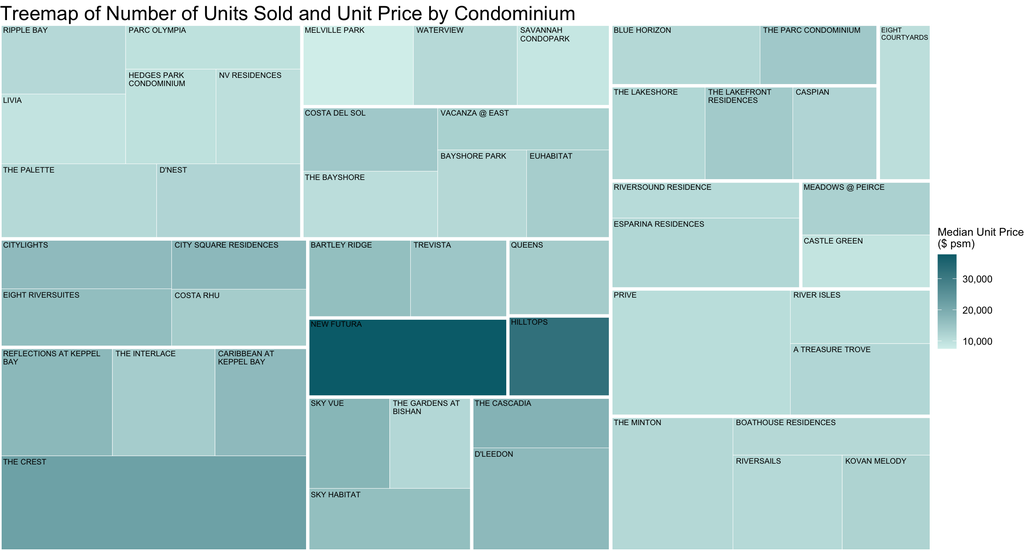

```r
ggplot(
  project_top50,
  aes(
    area = `Total Unit Sold`,
    fill = `Median Unit Price ($ psm)`,
    subgroup = `Planning Region`,
    subgroup2 = `Planning Area`,
    label = `Project Name`
  )
) +
  geom_treemap(colour = "white", linewidth = 0.7) +
  geom_treemap_subgroup2_border(colour = "white", linewidth = 1.1) +
  geom_treemap_subgroup_border(colour = "white", linewidth = 2) +
  geom_treemap_text(
    colour = "black",
    place = "topleft",
    reflow = TRUE,
    size = 7,
    min.size = 3
  ) +
  scale_fill_gradient(
    low = "#D7F0ED",
    high = "#006D7A",
    labels = comma
  ) +
  labs(
    title = "Treemap of Number of Units Sold and Unit Price by Condominium",
    fill = "Median Unit Price\n($ psm)"
  ) +
  theme_void() +
  theme(
    plot.title = element_text(size = 18, hjust = 0),
    legend.position = "right",
    legend.title = element_text(size = 10),
    legend.text = element_text(size = 9)
  )
```

This version is closer to a Tableau-style treemap. It keeps the project hierarchy but limits the number of project labels to prevent visual clutter.

## 7 Designing Interactive Treemap using d3treeR

Chapter 16 also introduces interactive treemaps using `d3treeR`. However, `d3treeR` is usually installed from GitHub, not CRAN. To keep this website stable on Vercel, the code is shown but not executed.

```r
# install.packages("devtools")
# devtools::install_github("timelyportfolio/d3treeR")

library(d3treeR)

tm <- treemap(
  area_summary,
  index = c("Planning Region", "Planning Area"),
  vSize = "Total Unit Sold",
  vColor = "Median Unit Price ($ psm)",
  type = "manual",
  palette = c("#D7F0ED", "#93D1CC", "#3FA7B3", "#006D7A"),
  algorithm = "squarified",
  title = "Interactive Treemap"
)

d3tree(tm, rootname = "Singapore")
```

## 8 Summary

Treemap is suitable when the data has a clear hierarchy. In this exercise, the hierarchy is based on planning region, planning area, and project name.

The key technical points are:

- `group_by()` and `summarise()` convert transaction-level data into aggregated data;
- `index` defines the hierarchy in the `treemap` package;
- `vSize` controls rectangle size;
- `vColor` controls rectangle colour;
- `type = "value"` maps colour intensity according to a numerical variable;
- `type = "manual"` gives more direct control over the colour palette;
- `palette` controls the colour scheme;
- `algorithm` controls the treemap layout;
- `sortID` controls rectangle ordering;
- `treemapify` provides a cleaner ggplot2-style approach;
- limiting the number of project labels is necessary for readability.

## 9 References

- R for Visual Analytics, Chapter 16: Treemap Visualisation with R.
- `treemap` R package.
- `treemapify` R package.
- `tidyverse` R package.